# Exploring Weather Trends

## Extracting the data

**I have extracted data from the given database, using SQL queries.**

*2 datasets extracted*

- Global Temperature ('global_data.csv') USING:

  > SELECT *  
  > FROM global_data
- City Temerature ('delhi_temp.csv') As I live in New Delhi, India.

> SELECT *  
> FROM city_data  
> WHERE Country = 'India' AND City = 'Delhi'

```python
# Impoting the python libraries and the dataset.
import pandas as pd
import matplotlib.pyplot as plt
import numpy as np
import seaborn as sb
%matplotlib inline

df_global = pd.read_csv('global_data.csv')
df_delhi = pd.read_csv('delhi_temp.csv')
```

## Exploring the datasets

```python
df_global.sample()
```

|  | year | avg_temp |
| --- | --- | --- |
| 73 | 1823 | 7.72 |

```python
df_delhi.sample()
```

|  | year | city | country | avg_temp |
| --- | --- | --- | --- | --- |
| 76 | 1872 | Delhi | India | 24.94 |

```python
df_global.info()
```

```
<class 'pandas.core.frame.DataFrame'>
RangeIndex: 266 entries, 0 to 265
Data columns (total 2 columns):
year        266 non-null int64
avg_temp    266 non-null float64
dtypes: float64(1), int64(1)
memory usage: 4.2 KB
```

```python
df_delhi.info()
```

```
<class 'pandas.core.frame.DataFrame'>
RangeIndex: 218 entries, 0 to 217
Data columns (total 4 columns):
year        218 non-null int64
city        218 non-null object
country     218 non-null object
avg_temp    201 non-null float64
dtypes: float64(1), int64(1), object(2)
memory usage: 6.9+ KB
```

```python
pd.isna(df_delhi.avg_temp).sum()
```

```
17
```

```python
df_delhi[df_delhi['avg_temp'].isnull()]
```

|  | year | city | country | avg_temp |
| --- | --- | --- | --- | --- |
| 12 | 1808 | Delhi | India | NaN |
| 13 | 1809 | Delhi | India | NaN |
| 14 | 1810 | Delhi | India | NaN |
| 15 | 1811 | Delhi | India | NaN |
| 16 | 1812 | Delhi | India | NaN |
| 62 | 1858 | Delhi | India | NaN |
| 63 | 1859 | Delhi | India | NaN |
| 64 | 1860 | Delhi | India | NaN |
| 65 | 1861 | Delhi | India | NaN |
| 66 | 1862 | Delhi | India | NaN |
| 67 | 1863 | Delhi | India | NaN |
| 68 | 1864 | Delhi | India | NaN |
| 69 | 1865 | Delhi | India | NaN |
| 70 | 1866 | Delhi | India | NaN |
| 71 | 1867 | Delhi | India | NaN |
| 72 | 1868 | Delhi | India | NaN |
| 73 | 1869 | Delhi | India | NaN |

## Assessment :

- `17` null values in delhi dataset.
- Betweeen years **1808** and **1869** average temperature values are missing at variarous places.

## Solution :

- We know that null values will create problems later.
- We will consider data in both the datasets after **1869** to prevent future problems.

```python
df_delhi = df_delhi.query('year > 1869')
df_delhi.info()
```

```
<class 'pandas.core.frame.DataFrame'>
Int64Index: 144 entries, 74 to 217
Data columns (total 4 columns):
year        144 non-null int64
city        144 non-null object
country     144 non-null object
avg_temp    144 non-null float64
dtypes: float64(1), int64(1), object(2)
memory usage: 5.6+ KB
```

```python
df_global = df_global.query('year > 1869')
df_global.info()
```

```
<class 'pandas.core.frame.DataFrame'>
Int64Index: 146 entries, 120 to 265
Data columns (total 2 columns):
year        146 non-null int64
avg_temp    146 non-null float64
dtypes: float64(1), int64(1)
memory usage: 3.4 KB
```

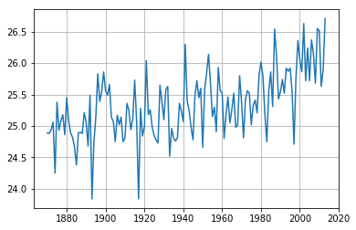

```python
plt.plot(df_delhi['year'], df_delhi['avg_temp'], label = "Delhi")
plt.grid(True)
plt.show()
```

## Assessment :

- As we plot average annual temperature over time, it creates graphs that is not easy to read.

## Solution :

- To create `moving average` of average temperature to smooth out the graph lines.

```python
global_mavg = df_global['avg_temp'].rolling(10).mean()
delhi_mavg = df_delhi['avg_temp'].rolling(10).mean()
```